# Лабораторная работа №11

Настройка безопасного удалённого доступа по протоколу SSH

Гашимова Эсма Эльшан кызы

1132247520@rudn.ru

Российский университет дружбы народов

2026-10-30

# Цели и задачи работы

## Цель лабораторной работы

Приобретение практических навыков настройки и администрирования безопасного удалённого доступа к серверу по протоколу SSH в операционной системе Rocky Linux.

Настроить ограничения доступа пользователей, дополнительные порты SSH и аутентификацию по ключу. Организовать SSH-туннель с перенаправлением TCP-портов, проверить удалённый запуск консольных и графических приложений, а также подготовить скрипт автоматизации настройки SSH-сервера с помощью Vagrant.

# Процесс выполнения лабораторной работы

## Проверка SSH-подключения пользователя root

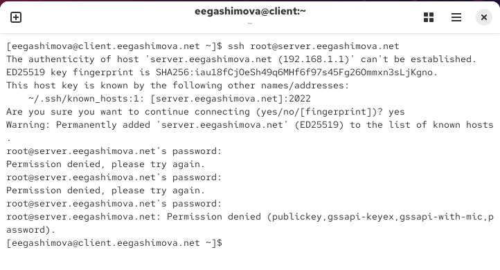

Попытка подключения к серверу по SSH от имени пользователя root

## Запрет удалённого доступа пользователю root

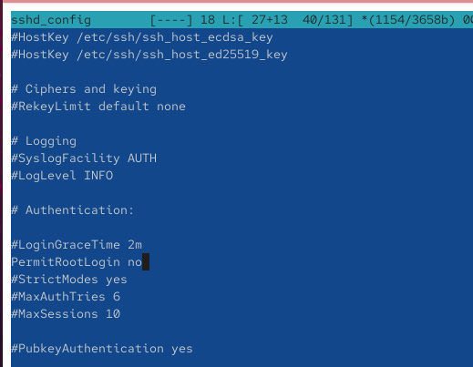

Настройка параметра PermitRootLogin no в конфигурации SSH

## Проверка ограничения доступа пользователя root

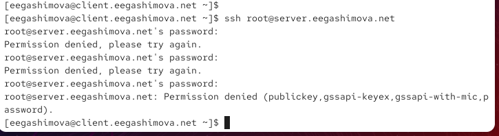

Проверка запрета удалённого подключения пользователя root

## Проверка подключения обычного пользователя

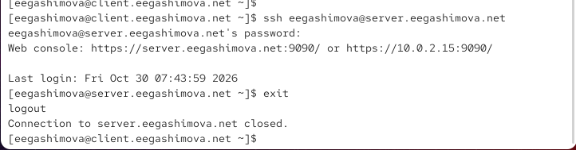

Проверка SSH-подключения к серверу под пользователем eegashimova

## Ограничение списка пользователей SSH

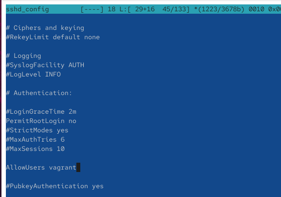

Настройка параметра AllowUsers для разрешения доступа пользователю vagrant

## Проверка запрета доступа пользователя

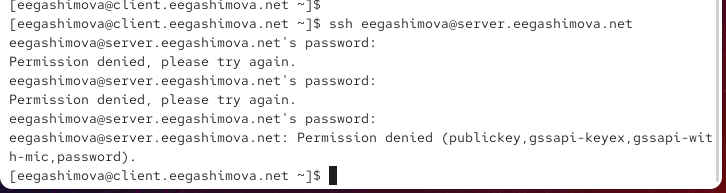

Проверка ограничения SSH-доступа для пользователя eegashimova

## Добавление пользователя в список разрешённых

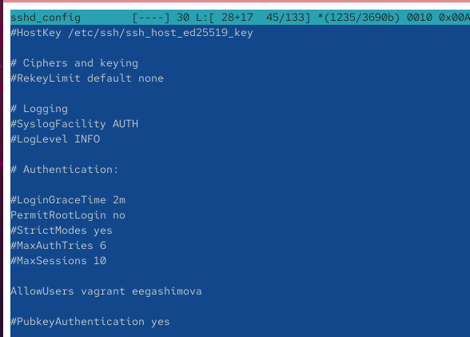

Настройка AllowUsers для пользователей vagrant и eegashimova

## Проверка подключения разрешённого пользователя

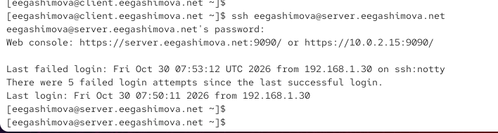

Успешное SSH-подключение пользователя eegashimova после изменения конфигурации

## Настройка дополнительных портов SSH

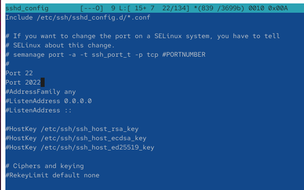

Настройка SSH-сервера для прослушивания портов 22 и 2022

## Проверка состояния SSH-службы

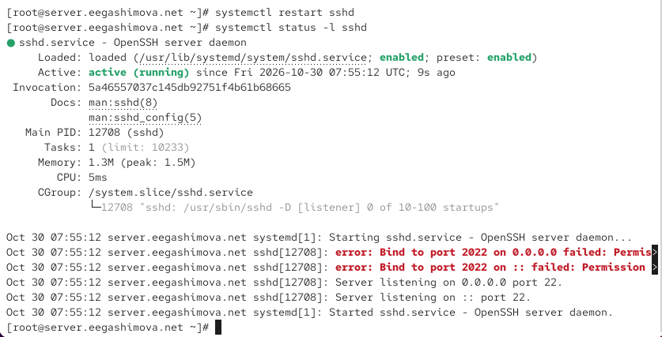

Обнаружение ошибки доступа к дополнительному TCP-порту 2022

## Анализ ограничений SELinux

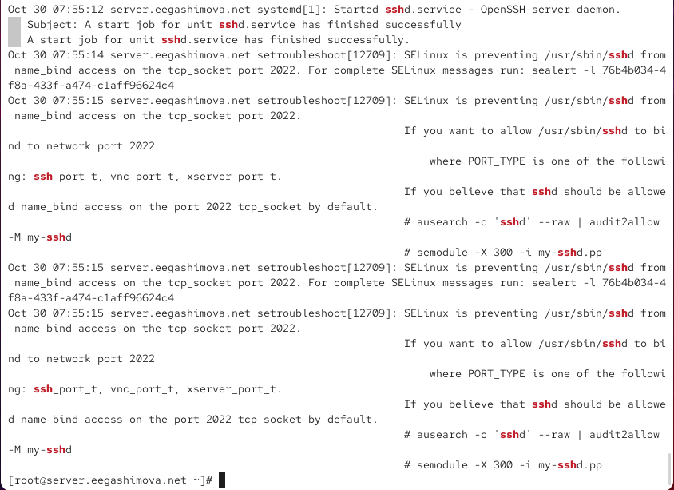

Анализ системных сообщений SELinux о блокировке TCP-порта 2022

## Настройка SELinux и межсетевого экрана

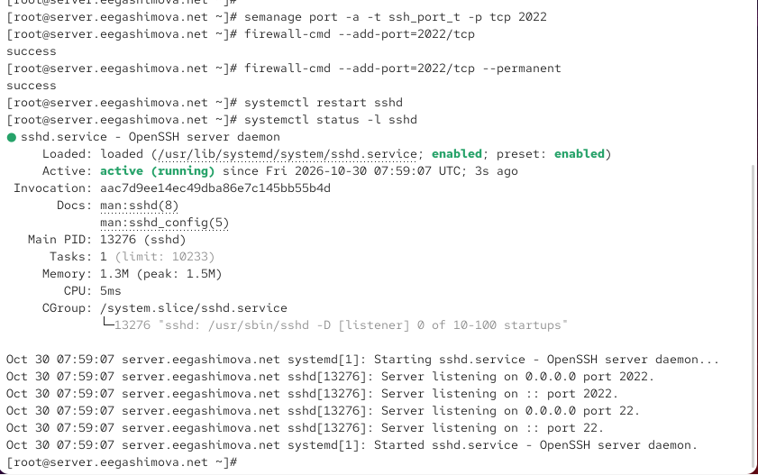

Разрешение использования порта 2022 и проверка состояния SSH-службы

## Проверка подключения через порты 22 и 2022

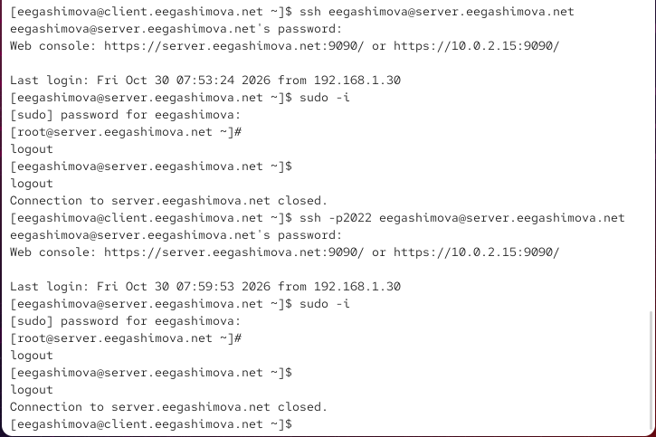

Проверка SSH-подключений и получения прав суперпользователя

## Настройка аутентификации по SSH-ключу

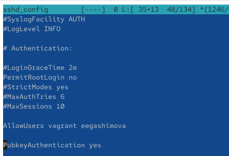

Разрешение аутентификации по открытому ключу в конфигурации SSH

## Генерация пары SSH-ключей

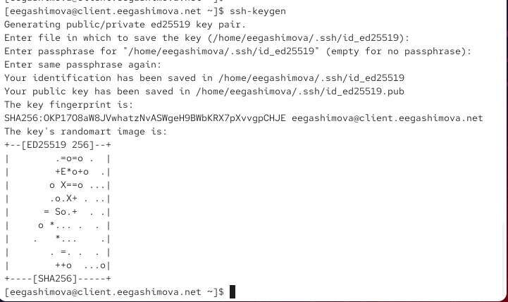

Создание пары открытого и закрытого ключей ED25519 на клиенте

## Копирование открытого ключа на сервер

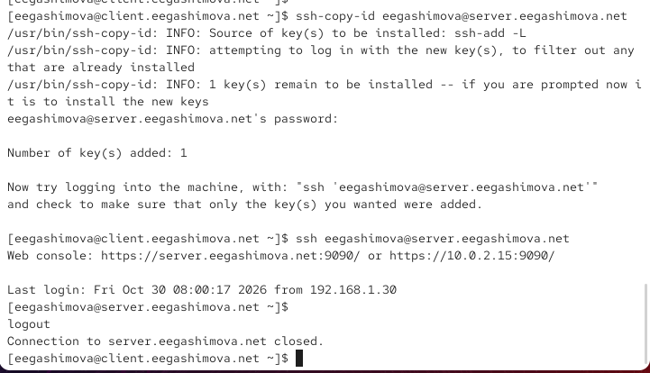

Установка открытого SSH-ключа и проверка подключения без пароля

## Организация SSH-туннеля

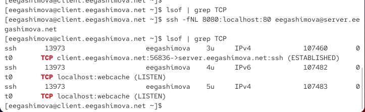

Создание SSH-туннеля с перенаправлением порта 8080 на порт 80

## Проверка перенаправления TCP-портов

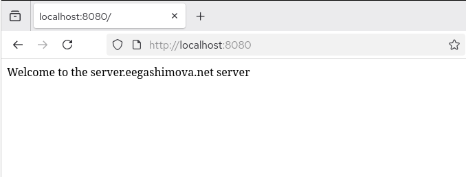

Проверка работы SSH-туннеля в браузере по адресу localhost:8080

## Выполнение удалённых консольных команд

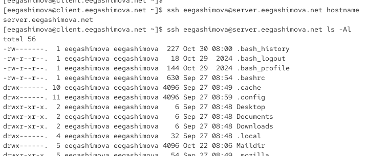

Удалённое выполнение команд hostname и ls через SSH

## Запуск консольного почтового приложения

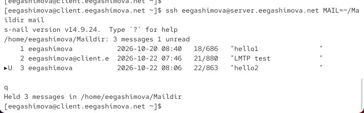

Просмотр почтовых сообщений на сервере через SSH с помощью mail

## Настройка перенаправления графических приложений

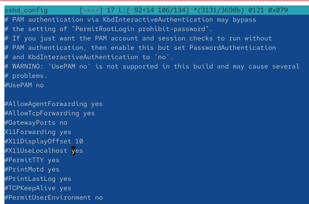

Разрешение X11Forwarding в конфигурации SSH-сервера

## Проверка запуска графического приложения через SSH

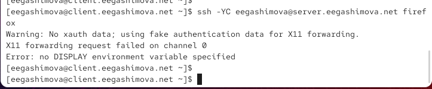

Попытка запуска Firefox через SSH и ошибка перенаправления X11

## Подготовка конфигурационных файлов для Vagrant

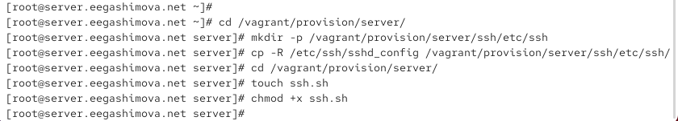

Создание каталогов конфигурации SSH и исполняемого скрипта ssh.sh

## Создание скрипта автоматизации SSH

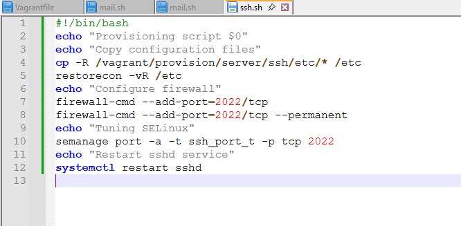

Редактирование скрипта ssh.sh для автоматической настройки SSH-сервера

# Результаты работы

## Настройка ограничений удалённого доступа

На виртуальной машине `server` настроен запрет удалённого подключения пользователя `root` с помощью параметра `PermitRootLogin no`. С использованием директивы `AllowUsers` доступ по SSH ограничен пользователями `vagrant` и `eegashimova`.

Проверена корректность установленных ограничений путём выполнения успешных и неуспешных попыток подключения с виртуальной машины `client`.

## Настройка дополнительных портов и аутентификации

SSH-сервер настроен для работы через TCP-порты `22` и `2022`. Для дополнительного порта изменены правила SELinux и межсетевого экрана `firewalld`. Успешное подключение через оба порта подтверждено проверками.

Настроена аутентификация по открытому ключу ED25519. Проверена возможность подключения пользователя `eegashimova` без ввода пароля учётной записи удалённого сервера.

## Организация SSH-туннеля

Создан защищённый SSH-туннель с перенаправлением соединений с локального порта `8080` на порт `80` удалённого сервера.

Работоспособность туннеля подтверждена открытием веб-страницы сервера через браузер по адресу `http://localhost:8080`.

## Удалённый запуск приложений

Успешно выполнены удалённые консольные команды `hostname` и `ls -Al`, а также запущено почтовое приложение `mail` для просмотра сообщений на сервере.

Настроен параметр `X11Forwarding yes` и выполнена попытка запуска Firefox через SSH. Запуск графического приложения завершился ошибкой перенаправления X11, требующей дополнительной настройки графического окружения.

# Вывод

В ходе лабораторной работы была выполнена настройка безопасного удалённого доступа по протоколу SSH на виртуальной машине `server`.

Реализованы ограничения доступа пользователей, настроена работа SSH через порты `22` и `2022`, а также организована аутентификация по криптографическому ключу ED25519.

На виртуальной машине `client` проверена работа SSH-туннеля с перенаправлением TCP-портов и выполнен запуск удалённых консольных приложений. При проверке X11Forwarding выявлена ошибка графического перенаправления.